# Online Bayesian FDR Control

Arjun Biddanda and Joseph Marcus

March 15, 2016

# Online Hypothesis Testing

Imagine that new data is presented to us sequentially over time. There are many scenarios where this might apply:

- High frequency stock trading
- A/B testing for internet advertisements
- Sequential genetic / clinical studies

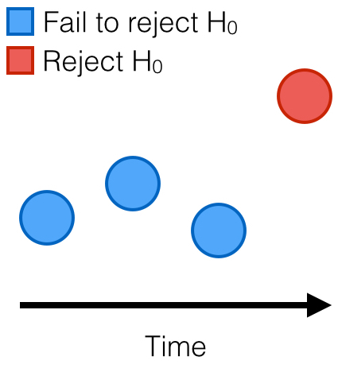

# Methods for Online Testing

Previous methods for controlling FDR in online settings use heuristics that readily make decisions at each time point. Some of these methods include:

- Level Based on Number of Discoveries (LBOND)$^{1}$
- Level Based on *Recent* Discoveries (LBORD)$^{1}$
- $\alpha$-investing$^{2}$

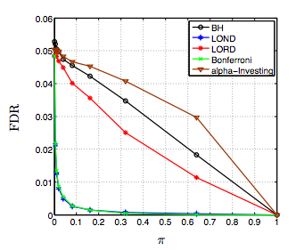

1) Javanmard and Montanari 2015  
2) Foster and Stine 2007

# Previous Methods

*($\alpha$-investing)*

Define a wealth function $w(t)$. Rejections add to wealth and failing to reject takes away wealth:

1. $w(t=0) = \alpha$
2. At time $t$ choose $\alpha_t \leq \frac{w(t-1)}{1 + w(t - 1)}$
3. Define $w(t)$ as a function of $w(t-1)$
   $$w(t) =
   \begin{cases}
   w(t-1) + \alpha & P_t \leq \alpha_t \\
   w(t-1) - \frac{\alpha_t}{1 - \alpha_t} & P_t > \alpha_t
   \end{cases}$$

# Previous Methods

*(LBOND/LBORD)*

1. At time $t$ set $\alpha_t = \beta_t \cdot max\{1, D_{t - 1}\}$ where $\sum^\infty_{t=1} \beta_t = \alpha$
2. Reject if $P_t \leq \alpha_t$
3. If discovery add to $D$

*LBORD follows the same general idea, but we keep track of when the last discovery was made*

# Challenges in Online FDR Control

- Strict decision rules at each time point (can’t update previous discoveries)
- Controlling Power and FDR simultaneously through a dynamic time-series is difficult
- Focus on limited features of the data (i.e. only number of discoveries)

# A Bayesian Approach to FDR

A Bayesian approach to FDR control considers an underlying mixture distribution consisting of *null* and *signal* components, and controls FDR based on the parameters of this distribution.

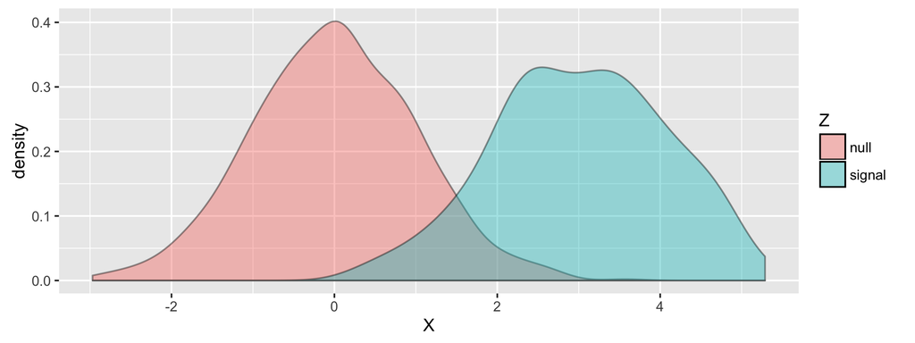

# Model Assumptions

- $X$ - a test statistic
- $\pi_0$ - proportion of nulls
- $\mu_1$ - mean of the signals
- $\sigma^2_1$ - variance of the signals

$X$ can be modeled as a mixture of Gaussians:

$$X \mid \pi_0, \mu_1, \sigma^2_1 \sim \pi_0 N(0,1) + (1 - \pi_0) N(\mu_1, \sigma^2_1)$$

# Controlling Bayesian FDR

If we assume that we only know the parameters of the null component, but we have to estimate $\pi_0, \mu_1, \sigma^2_1$ then we can control FDR at level:

$$\alpha = \frac{\pi_0(1 - \Phi(\hat{x}))}{\pi_0(1 - \Phi(\hat{x})) + (1-\pi_0)\left(1 - \Phi\left(\frac{\hat{x} -\mu_1}{\sigma_1}\right)\right)}$$

Where we reject $X$ if $X > \hat{x}$.

*How should we do the parameter estimation?*

# Gibbs Sampler

Let $Z$ be a latent indicator for being a signal ($Z=1$).

*Priors:*

$\pi_0 \sim Beta(\alpha, \beta)$  
$\phi_1 \sim Gamma\left(\frac{a}{2}, \frac{b}{2}\right)$  
$\mu_1 \mid \phi_1 \sim Normal\left(\mu^{*}, \frac{1}{\alpha^{*} \phi_1}\right)$

*Posteriors:*

$\pi_0 \mid X, Z = 0 \sim Beta(\alpha + n_0, \beta + n_1)$  
$\phi_1 \mid X, Z \sim Gamma\left(\frac{a + n_1}{2}, b + \sum_{t:z_t = 1} (x_t - \mu_1)^2\right)$  
$\mu_1 \mid X, Z, \phi_1 \sim Normal\left(\frac{\alpha^{*} \mu^{*} + n_1 + \bar{x_1}}{\alpha^{*} + n_1}, \frac{1}{(\alpha^{*} + n_1) \phi_1}\right)$

# Online Bayesian FDR

Here we propose to:

- Estimate the parameters of the mixture model at a given time interval using the Gibbs sampler described previously
- Use the estimated mixture model to control the FDR

*Our approach provides the ability to sample from the posterior of $Z$ when estimating the mixture model rather than fixing the number of discoveries as in LBOND and LBORD.*

# Simulation Scenario

- We simulate 1000 time points, and a Z-score from each time point given $\theta = \{\pi = 0.8, \mu_1 = 3, \sigma^2_1 = 1\}$

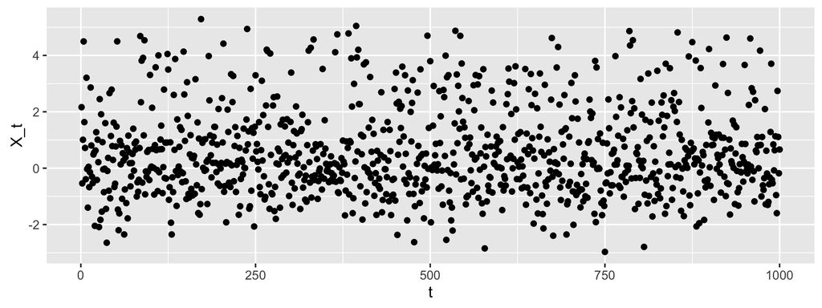

# Gibbs Results

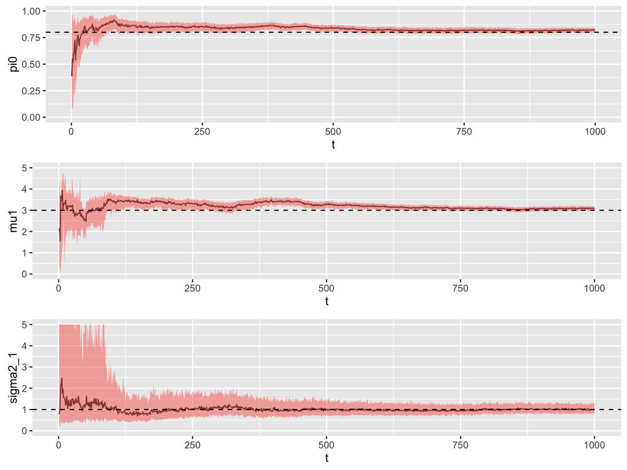

# Gibbs Results

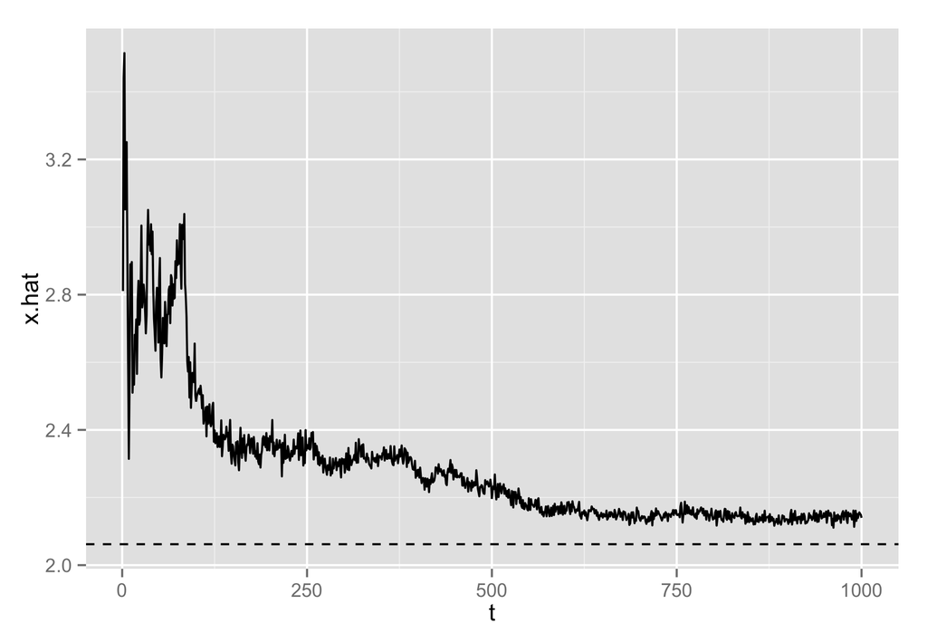

# FDP

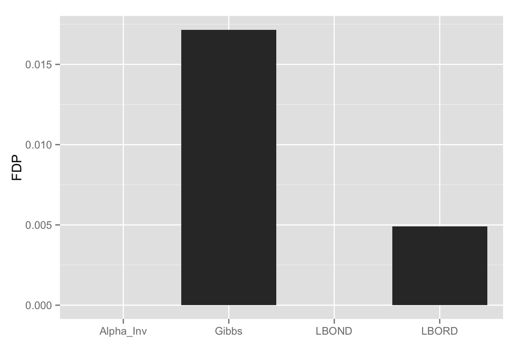

# Power

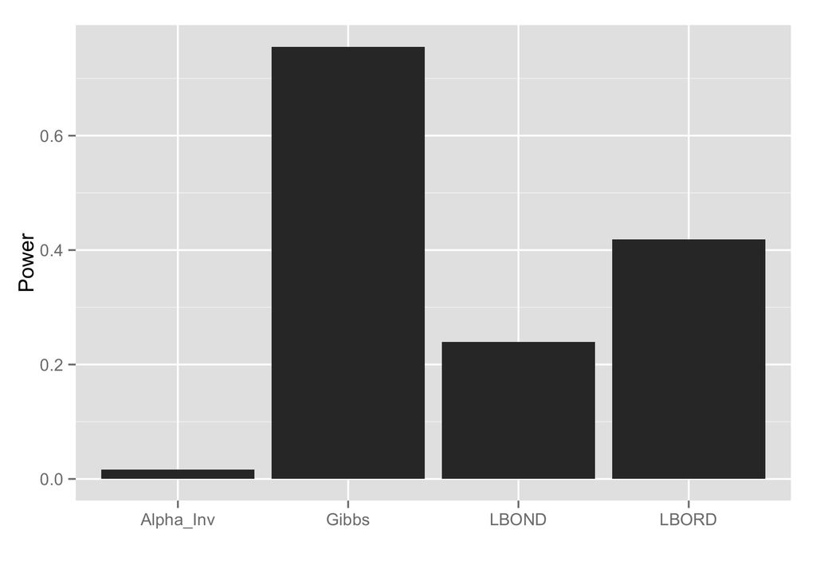

# Caveats

- Really difficult to estimate model parameters with small amount of data
- Gibbs Sampling at each time point can be quite intensive (especially for later time points)
- High FDP compared to previous approaches

# Further Directions

- More efficient inference procedure than MCMC
- Explore consequences of how frequently we re-estimate the model
- Correlation among the signals (i.e. simulate from a Markov Chain)
- Explore different modeling assumptions for signal and null distributions (i.e. multiple components in the mixture model)

# Acknowledgements

- Rina Foygel Barber
- Yuancheng Zhu

**Thank you!**